# U4L10 - Ensemble Learning

## Front Matter

```r
#Delete all objects from Environment - Use with caution
remove(list = ls())

#Load Libraries
library(tidyverse)
library(rpart)
library(rattle) #Include before randomForest so that randomForest::importance is not masked by rattle::importance
library(randomForest)
#Read in Data
titanic <- read.csv("../../sample_data/L08_titanic3.csv")
```

## Example - Generating a Bootstrap Sample in R

#### Part a - Generate a bootstrap sample using the first 10 rows and 4 columns of Titanic with a seed of 123

```r
#Create a temp copy of the dataset using the first 10 rows and first 4 columns
tempTitanic <- titanic[1:10, 1:4]
tempTitanic

#Sample the row numbers with replacement
set.seed(123)
bs1Ind <- sample(1:nrow(tempTitanic), nrow(tempTitanic), replace = TRUE)
set.seed(NULL)

#View the select rows
table(bs1Ind)

#View the dataset
bs1Train <- tempTitanic[bs1Ind, ]
```

[output not shown]

The in-bag observations are: In bag observations are the ones that are in the sample.

The out-of-bag (OOB) observations are: Out of bag observations are the ones that were in the origional data but not in the bootstrapped sample

## Example - Bagging Regression Trees

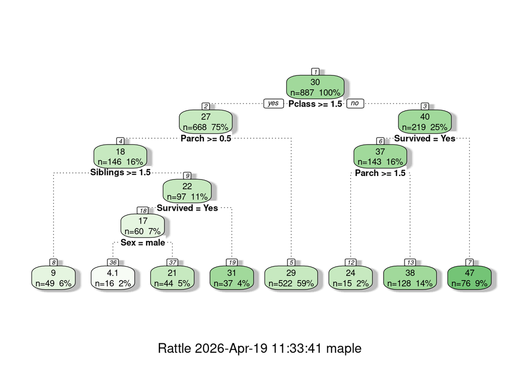

```r
#Generate First Bootstrap Sample
set.seed(123)
bs1Ind <- sample(1:nrow(titanic), nrow(titanic), replace = TRUE)
set.seed(NULL)

bs1Train <- titanic[bs1Ind, ]

#Train a Regression Tree
regTree1 <- rpart(Age ~ ., data = bs1Train, method = "anova")

#Plot Tree
fancyRpartPlot(regTree1, cex = 0.7)
```

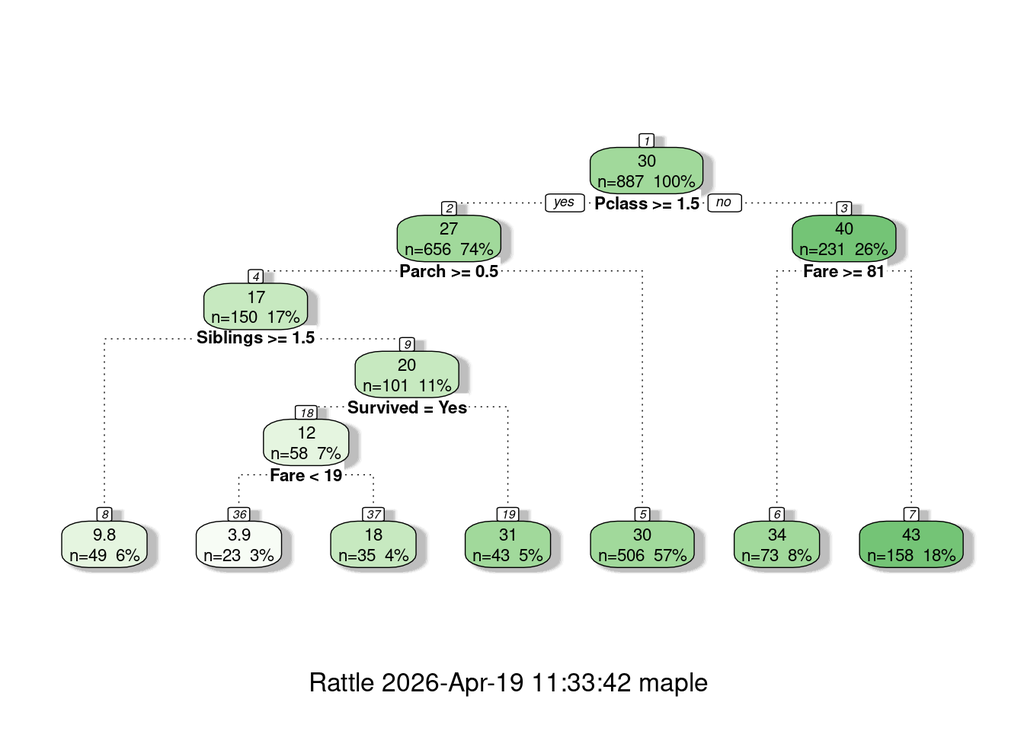

```r
#Generate Second Bootstrap Sample
set.seed(1234)
bs2Ind <- sample(1:nrow(titanic), nrow(titanic), replace = TRUE)
set.seed(NULL)

bs2Train <- titanic[bs2Ind, ]

#Train a Regression Tree
regTree2 <- rpart(Age ~ ., data = bs2Train, method = "anova")

#Plot Tree
fancyRpartPlot(regTree2, cex = 0.7)
```

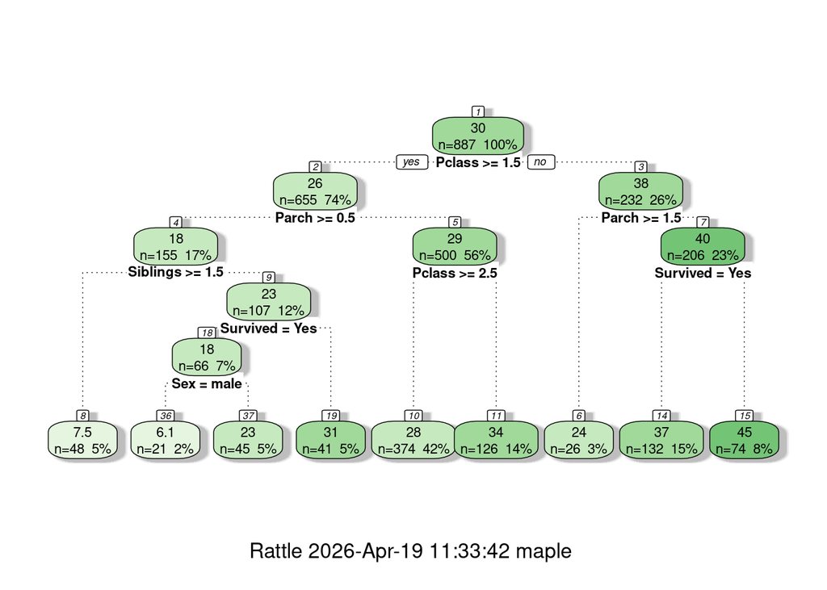

```r
#Generate Third Bootstrap Sample
set.seed(23)
bs3Ind <- sample(1:nrow(titanic), nrow(titanic), replace = TRUE)
set.seed(NULL)

bs3Train <- titanic[bs3Ind, ]

#Train a Regression Tree
regTree3 <- rpart(Age ~ ., data = bs3Train, method = "anova")

#Plot Tree
fancyRpartPlot(regTree3, cex = 0.7)
```

## Example - Random Forest in R using Titanic Data

## Part a - Prepare the data by performing an 80/20 training/validation split using a seed of 123.

```r
#Perform an 80/20 training/validation split
set.seed(123)
trainInd <- sample(1:nrow(titanic), floor(0.8 * nrow(titanic)))
set.seed(NULL)

Train <- titanic[trainInd, ]
Validation <- titanic[-trainInd, ]
```

#### Part b - Build a random forest for predicting whether a person survives based on the other variables in the dataset. The forest should consist of 500 trees. Each time a split is considered, use 3 variables. Explain the error message

```r
rfModel <- randomForest(Survived ~ ., data = Train, ntree = 500, mtry = 3) #mytry is the number of features, the m number of variables to try
```

```
## Error in `y - ymean`:
## ! non-numeric argument to binary operator
```

#### Part c - Fix the code to eliminate the error message and train the model.

```r
rfModel <- randomForest(as.factor(Survived) ~ ., data = Train, ntree = 500, mtry = 3)
```

#### Part d - What are the default options for ntree and mtry?

The default for mtry depends on whether it is a classification or regression task. The help documentation has a lot of the details.

#### Part e - Find the probabilities of survival for the first 6 passengers in the validation set. Are you getting the same values?

```r
#Obtain Predicted Probabilities
predProb <- predict(rfModel, newdata = Validation, type = "prob")

#Display Predicted Probabilities for first 6 passengers
head(predProb)
```

```
##       No   Yes
## 1  0.998 0.002
## 3  0.636 0.364
## 7  0.748 0.252
## 12 0.330 0.670
## 15 0.210 0.790
## 18 1.000 0.000
```

- The probabilities may differ from what is shown on the handout. Also, if you rerun the code, the probabilities may change.
- In random forest, there is randomness involved each time we build a tree since we have to select a bootstrap sample. If mtry is less than p (number of variables in dataset), there is also a random selection of mtry variables each time we consider making a split.
- To get reproducible results, use a seed.

#### Part f - Using a seed of 123 for constructing the forest, report the confusion matrix for the testing data and the overall accuracy of the method.

```r
#Build model using a seed of 123
set.seed(123)
rfModel <- randomForest(as.factor(Survived) ~ .,
                        data = Train,
                        ntree = 500,
                        mtry = 3)
set.seed(NULL)

#Obtain predicted probabilities - not needed for confusion matrix but included to show we all get same probabilities when using the same seed
predProb <- predict(rfModel, newdata = Validation, type = "prob")
head(predProb)
```

```
##       No   Yes
## 1  0.996 0.004
## 3  0.612 0.388
## 7  0.770 0.230
## 12 0.314 0.686
## 15 0.222 0.778
## 18 0.998 0.002
```

```r
#To create the confusion matrix, we need to determine which class (No or Yes) is more likely. Although we could define a threshold and compare probabilities as we have done in the past, things are more challenging if y has more than 2 classes. So, let R pick for us.
predSurv <- predict(rfModel , newdata = Validation, type = "response")

#Create confusion matrix
table(predSurv, Validation$Survived)
```

```
##
## predSurv No Yes
##      No  92  23
##      Yes 14  49
```

```r
#Calculate accuracy
mean(Validation$Survived == predSurv)
```

```
## [1] 0.7921348
```

#### Part g - How does the confusion matrix from the last problem differ from rfModel$confusion?

```r
#Display Confusion Matrix
rfModel$confusion
```

```
##      No Yes class.error
## No  395  44   0.1002278
## Yes  72 198   0.2666667
```

```r
#Calculate accuracy
tempConfMat <- rfModel$confusion
sum(tempConfMat[1,1] + tempConfMat[2,2])/sum(tempConfMat[1:2,1:2])
```

```
## [1] 0.8363893
```

- The accuracy values are different.
- The total number of observations in this confusion matrix is more than the number of observations in the previous confusion matrix.
- The confusion matrix in this problem is based on predictions using the OOB data from the Training set. The earlier confusion matrix was based on the Validation set.